# survival analysis MOFA using MOFA scores based on transcriptomics

Aim : calculate scores based on transcriptomics and survival analysis between low and high score value

Analysis 1. Calculate factors based on linear combination of top 600 genes for each factor in swedish cohort 2. Survival analysis using Factor 8 (high/low) in swedish cohort 3. Survival analysis using Factor 8 (high/low) calculated from transcriptomics in swedish cohort

4. Calculate factors based on linear combination of top 600 genes for each factor in BeatAML cohort
5. Survival analysis using Factor 8 (high/low) calculated from transcriptomics in BeatAML cohort (chemotherapy)
6. Survival analysis using Factor 4 (high/low) calculated from transcriptomics in BeatAML cohort (sorafenib)
7. Survival analysis using Factor 2 (high/low) calculated from transcriptomics in BeatAML cohort (ven+aza)

### clean environment

```r
rm(list=ls())
```

### set directory

```r
    knitr::opts_knit$set(root.dir = normalizePath("/home/flomik/Code/MOFA_AML"))
```

```r
library(MOFA2)
library(data.table)
library(readxl)
library(ggplot2)
library(survival)
library(survminer)
library("smplot2")
library(MultiAssayExperiment)
library(gridExtra)
library(xlsx)
```

## load data

```r
load("/home/flomik/Data/MOFA_R_Objects/AML_MAexp_v05.RData")
ls()
```

```
[1] "MAexp" "pData"
```

```r
#source("/home/flomik/Code/Hallmarks_AML/src/functions_Hallmarks.R")

load("/home/flomik/Data/MOFA_R_Objects/MOFA_v04_train_list.RData")
```

## load annotations

```r
annot.df <- read.table("data/MOFA/MOFA_v04_annot_features.txt", sep="\t", header = T, stringsAsFactors = F)
```

## Select MOFA object

```r
mofa.sel <- select_model(mofa.list)
```

## extract top features

```r
path_factors <- "data/MOFA/AML_MOFAplus_top_factors_v04_f600 (1).xlsx"
RNA_factors=NULL
for (i in 1:11){
  factorName=paste0("Factor",i,"_RNAseq")
  cat(factorName," ")
  dat=read_excel(path_factors,sheet=factorName)
  dat=data.table(dat)
  print(nrow(dat))
  RNA_factors[[i]]=dat
}
```

```
Factor1_RNAseq  [1] 600
Factor2_RNAseq  [1] 600
Factor3_RNAseq  [1] 600
Factor4_RNAseq  [1] 600
Factor5_RNAseq  [1] 600
Factor6_RNAseq  [1] 600
Factor7_RNAseq  [1] 600
Factor8_RNAseq  [1] 600
Factor9_RNAseq  [1] 600
Factor10_RNAseq  [1] 600
Factor11_RNAseq  [1] 600
```

```r
RNAfac=do.call(rbind,RNA_factors)
RNAfac$feature=gsub(".g","",RNAfac$feature)
## set thresholds for each factor
factorNames=unique(RNAfac$factor)
topGeneThres=c(9,10,2,6,4,1,2,3,3,6,3)
names(topGeneThres)=factorNames
```

## Extract transcriptomics

```r
gex <- data.frame(mofa.sel@data[[5]]$AML)
gex <-gex[!is.na(gex),]
rownames(gex) <- gsub(".g", "", rownames(gex))
gex$stable_id <- rownames(gex)
txn <- gex[!is.na(gex$ALBB13002),]
txn$ALG200931 <- NULL
condition <- data.frame(patient_id = colnames(txn))
```

## Calculate factor scores transcriptomics

```r
for (i in 1:11) {
  fname <- paste0("Factor", i)
  myFactor1 <- RNAfac[RNAfac$factor==fname,]
  pick <- txn$stable_id %in% myFactor1$feature
  x=txn[pick,drop=FALSE,]
  x=t(x[,colnames(x) != "stable_id"])
  beta <- myFactor1$value[match(colnames(x), myFactor1$feature)]
  yval=t(t(x) * beta)
  yval=rowSums(yval)
  weight <- data.frame(yval)
  colnames(weight) <- fname
  weight$patient_id <- rownames(weight)
  yval <- data.frame(patient_id = names(yval), score = yval)
  yval$group <- as.integer(yval$score > median(yval$score))+1
  colnames(yval)[2:3] <- paste0(fname, "_", colnames(yval)[2:3])
  condition <- merge(condition, yval, by = "patient_id")
}
```

```r
write.csv(condition, "processing/MOFA_transcriptomics_scores.csv")
```

## extract DDHM values

```r
factors <- read_xlsx("/home/flomik/Code/MOFA_AML/data/MOFA/DDHMpatValue.xlsx")
patients <- factors$patient_id
rownames(factors) <- factors$patient_id
factors$sample <- NULL
factors$patient_id <- NULL
factors <- data.frame(lapply(factors, as.numeric))
factors$patient_id <- patients
txn <- condition[,colnames(condition) %in% c("patient_id", colnames(condition)[grepl("score", colnames(condition))])]
data <- merge(factors, txn, by = "patient_id")
```

```r
data$Factor4_score <- -1*data$Factor4_score
data$Factor8_score <- -1*data$Factor8_score
```

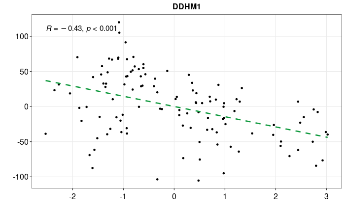

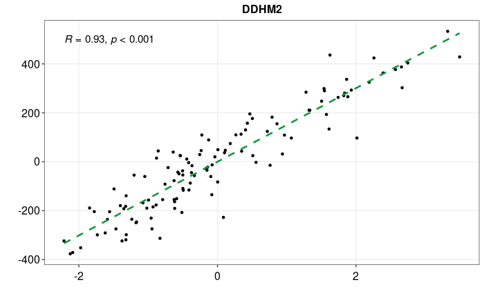

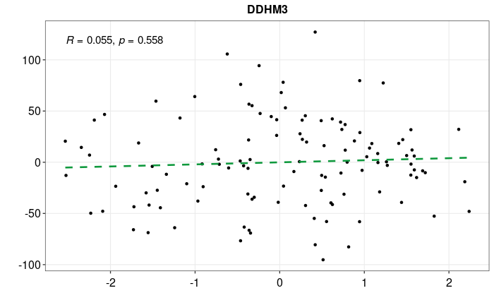

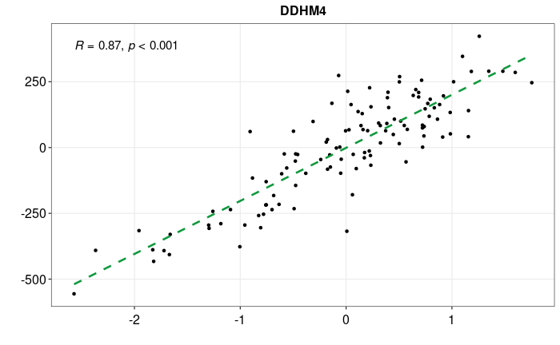

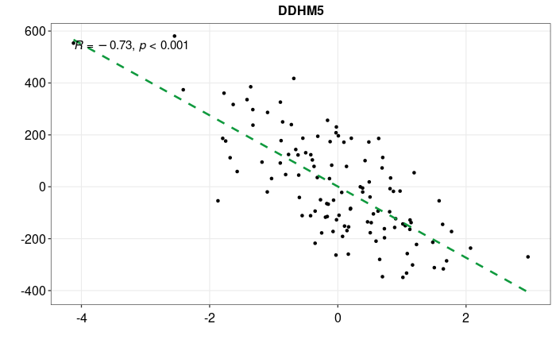

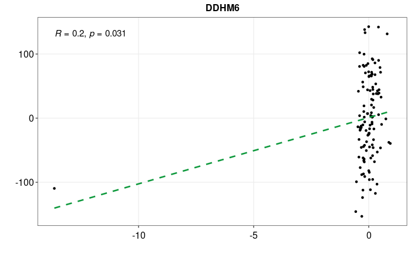

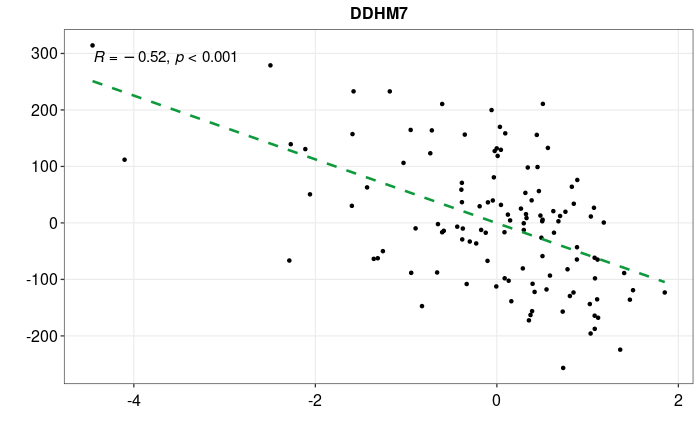

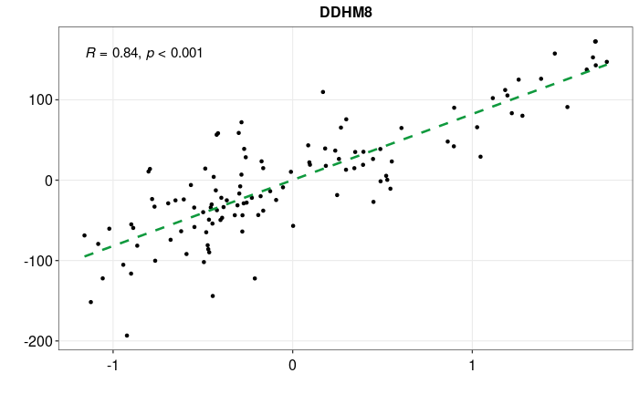

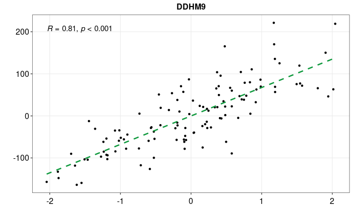

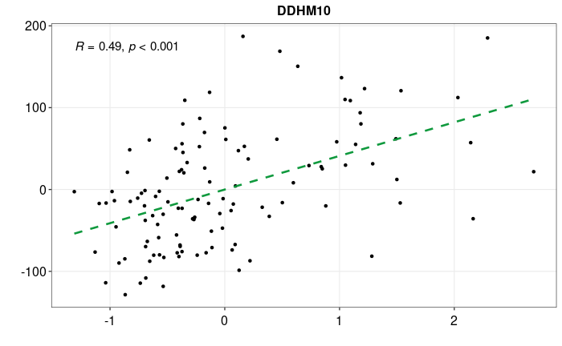

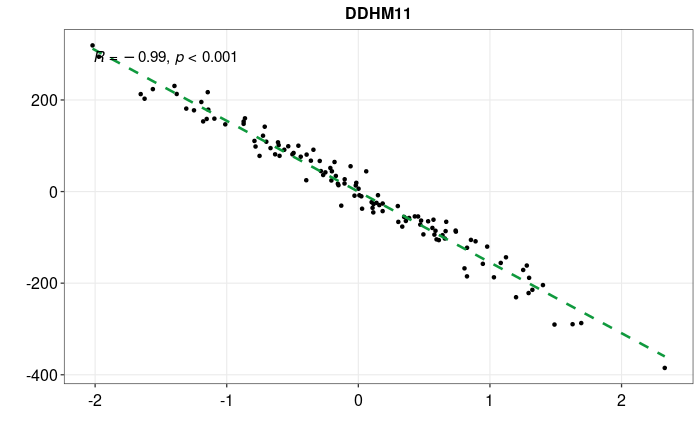

```r
myplots <- vector('list', 11)

for (i in 2:12) {
  myplots[[i-1]] <- local({
        i <- i
        a <- ggplot(data = data, mapping = aes(x = data[, i], y =data[, i+11])) +
          geom_point(size = 1) + xlab("") + ylab("")+theme_classic()+
          sm_statCorr( color = "#0f993d", corr_method = "pearson", linetype = "dashed")+
          ggtitle(paste0("DDHM", i-1))
        print(a)
    })
}
```

```r
colnames(data)[5]
```

```
[1] "DDHM4"
```

```r
colnames(data)[5+11]
```

```
[1] "Factor4_score"
```

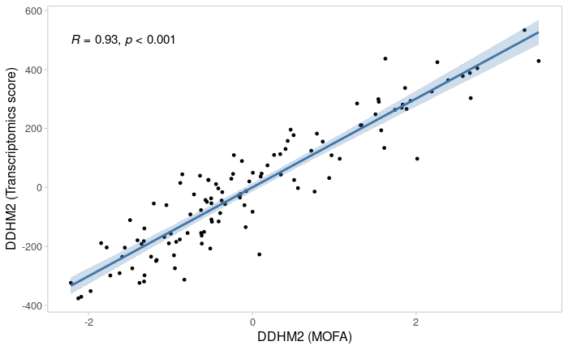

```r
a <- ggplot(data = data, mapping = aes(x = data[, 3], y =data[, 3+11])) +
          geom_point(size = 1) + xlab("DDHM2 (MOFA)") + ylab("DDHM2 (Transcriptomics score)")+
          sm_statCorr(corr_method = "pearson", size = 0.1) +
  geom_smooth(method=lm, level=0.95, colour = "#4076A9", fill = "#4076A9", alpha=0.25)+
  theme_light()+
  theme(panel.grid.major = element_blank(), panel.grid.minor = element_blank(),
                                      text=element_text(family="Helvetica", size=12))
a
ggsave("results/figures/scatter_plots_MOFA_vs_transcriptomics_Factor_2_v2.pdf", width = 4, height = 4, units = "in")
```

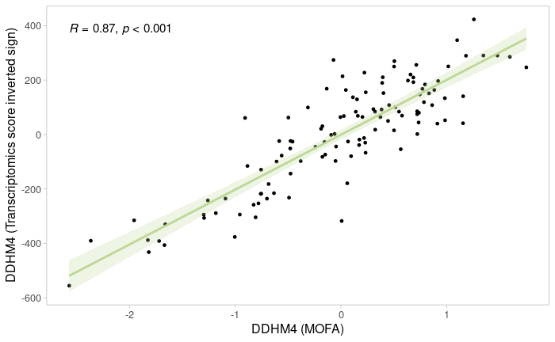

```r
a <- ggplot(data = data, mapping = aes(x = data[, 5], y =data[, 5+11])) +
          geom_point(size = 1) + xlab("DDHM4 (MOFA)") + ylab("DDHM4 (Transcriptomics score inverted sign)")+
          sm_statCorr(corr_method = "pearson", size = 0.1) +
  geom_smooth(method=lm, level=0.95, colour = "#BED797", fill = "#BED797", alpha=0.25)+
  theme_light()+
  theme(panel.grid.major = element_blank(), panel.grid.minor = element_blank(),
                                      text=element_text(family="Helvetica", size=12))
a
ggsave("results/figures/scatter_plots_MOFA_vs_transcriptomics_Factor_4_v2.pdf", width = 4, height = 4, units = "in")
```

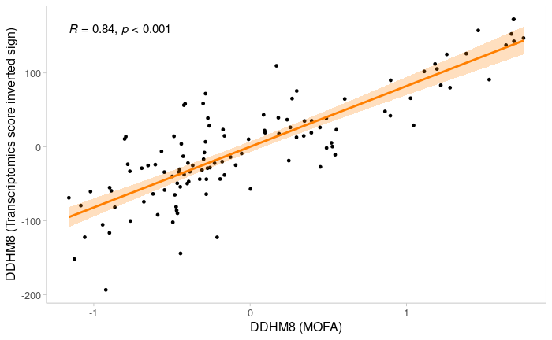

```r
a <- ggplot(data = data, mapping = aes(x = data[, 9], y =data[, 9+11])) +
          geom_point(size = 1) + xlab("DDHM8 (MOFA)") + ylab("DDHM8 (Transcriptomics score inverted sign)")+
          sm_statCorr(corr_method = "pearson", size = 0.1) +
  geom_smooth(method=lm, level=0.95, colour = "#FF7F00", fill = "#FF7F00", alpha=0.25)+
  theme_light()+
  theme(panel.grid.major = element_blank(), panel.grid.minor = element_blank(),
                                      text=element_text(family="Helvetica", size=12))
a
ggsave("results/figures/scatter_plots_MOFA_vs_transcriptomics_Factor_8_v2.pdf", width = 4, height = 4, units = "in")
```

```r
plots <- marrangeGrob(myplots, nrow = 4, ncol = 3, layout_matrix = matrix(
    seq_len(4 * 3),
    nrow = 4, ncol = 3,
    byrow = TRUE
  ))
ggsave("results/figures/scatter_plots_MOFA_vs_transcriptomics_v2.pdf", plots, width = 8, height = 8, units = "in")
```

## load clinical data

```r
clinical_data <- data.frame(pData)
clinical_data <- clinical_data[, colnames(clinical_data) %in% c("time_days", "status", "patient_id")]
clinical_data$survival <- clinical_data$time_days/365
data <- merge(factors, condition, by = "patient_id")
data <- merge(clinical_data, data, by = "patient_id")
```

## separate groups between high Factor 8 and low Factor 8

```r
data$Factor8_group <- paste0("G", data$Factor8_group)
data$Factor8_group_2 <- NA
data$status
```

```
  [1] 0 1 1 1 1 0 1 1 1 1 0 0 1 0 1 1 0 0 1 0 1 0 0 0 1 1 0 1 1 1 1 1 1 1 1 0 1 1 1 1 1 0 1 1 1 1 1 1 1 1 1 1 1 1 1 0 1 1 0 1 1 0 1 1 1 0 0 1 1 1 1 1 1 1 0 0 1 1 1 0
 [81] 0 1 1 1 1 0 1 1 0 1 1 1 1 1 1 0 1 1 1 0 0 1 1 1 1 1 0 0 1 0 1 1 0 0 1 0 1
```

```r
data$DDHM8_group <- NA
```

```r
data$DDHM8_group[data$DDHM8 > median(data$DDHM8)] <- 2
data$DDHM8_group[data$DDHM8 < median(data$DDHM8)] <- 1
```

```r
data$Factor8_score <- -1*data$Factor8_score
```

```r
data$Factor8_group_2[data$Factor8_score > median(data$Factor8_score)] <- 2
data$Factor8_group_2[data$Factor8_score < median(data$Factor8_score)] <- 1
```

```r
data$Factor8_group_2[is.na(data$Factor8_group_2)] <- 2
```

## Survival analysis

```r
# run cox regression based on groups
fit.surv <- survfit(Surv(survival, status) ~ DDHM8_group, data = data)

ggsurv <- ggsurvplot(fit.surv,
           data = data,
           risk.table = TRUE,
           conf.int = TRUE,
           size = 1,
           pval = TRUE,
           palette = c("#0000FF", "#FB0207"),
           legend.labs = c("m_lo", "m_hi"),
           ggtheme = theme_light(),
           tables.height = 0.23,
           xlim = c(0, 15),
           pval.coord = c(0,0),
           pval.size = 4.5,
           conf.int.alpha = 0.25)

ggsurv$plot <- ggsurv$plot + theme(panel.grid.major = element_blank(), panel.grid.minor = element_blank(), text=element_text(family="Helvetica", size=12)) +xlab("Time (years)")+
  theme(strip.text.x = element_blank(),
      strip.background = element_rect(colour="white", fill="white"),
      legend.position=c(.85,.85))+ggtitle("")

ggsurv$table <- ggsurv$table + theme(panel.grid.major = element_blank(), panel.grid.minor = element_blank(),
                                      text=element_text(family="Helvetica", size=12))

ggsurv
```

```r
pdf("results/figures/survival_curves_DDHM8_median.pdf", width = 4, height = 5)
print(ggsurv, newpage = FALSE)
```

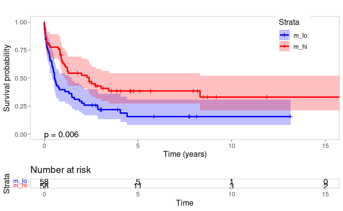

```r
dev.off()
```

```r
# run cox regression based on groups
fit.surv <- survfit(Surv(survival, status) ~ Factor8_group_2, data = data)

ggsurv <- ggsurvplot(fit.surv,
           data = data,
           risk.table = TRUE,
           conf.int = TRUE,
           size = 1,
           pval = TRUE,
           palette = c("#0000FF", "#FB0207"),
           legend.labs = c("t_lo", "t_hi"),
           ggtheme = theme_light(),
           tables.height = 0.23,
           xlim = c(0, 15),
           pval.coord = c(0,0),
           pval.size = 4.5,
           conf.int.alpha = 0.25)

ggsurv$plot <- ggsurv$plot + theme(panel.grid.major = element_blank(), panel.grid.minor = element_blank(), text=element_text(family="Helvetica", size=12)) +xlab("Time (years)")+
  theme(strip.text.x = element_blank(),
      strip.background = element_rect(colour="white", fill="white"),
      legend.position=c(.85,.85))

ggsurv$table <- ggsurv$table + theme(panel.grid.major = element_blank(), panel.grid.minor = element_blank(),
                                      text=element_text(family="Helvetica", size=12))+ggtitle("")

ggsurv
```

```r
pdf("results/figures/survival_curves_DDHM8_scores_txn_KI_median_inverted_sign.pdf", width = 4, height = 5)
print(ggsurv, newpage = FALSE)
```

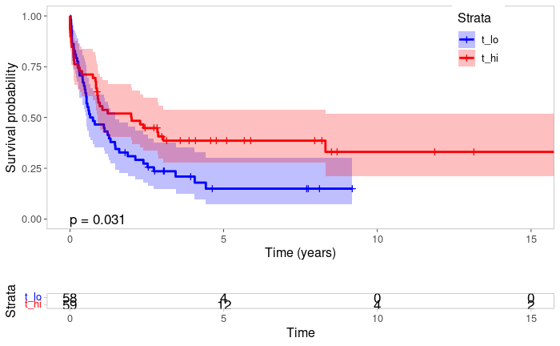

```r
dev.off()
```